# Assignment 10

## Try to submit as an HTML file

Print your Emory ID below

```python
print(2548361)
```

```
2548361
```

Import the "pandas" and "matplotlib.pyplot" libraries.

```python
# Write your answer here:
import pandas as pd
import matplotlib.pyplot as plt
```

In this assignment, we will work with a World Bank  
dataset on the proportion of urban population across  
countries, from 2016-2020.

- This is an example of a "panel"/"longitudinal" dataset  
  which contains information about the same unit (country)  
  over time.
  - This is in "long" format (see Lecture 21)

(a) Import data and parse dates

- Import "data_raw/wdi_long.csv"
- Create a new column called "date" which uses `pd.to_datetime(...,format = ...)`  
  to convert year to a date format
- To get full points use wild cards to establish the format.

Hint: See Lecture 20 for information about wild cards

```python
wdi= pd.read_csv("data_raw/wdi_long.csv")
wdi
```

|  | year | year_code | country_name | country_code | prop_urban |
| --- | --- | --- | --- | --- | --- |
| 0 | 2016 | YR2016 | Afghanistan | AFG | 25.020 |
| 1 | 2016 | YR2016 | Albania | ALB | 58.421 |
| 2 | 2016 | YR2016 | Algeria | DZA | 71.459 |
| 3 | 2016 | YR2016 | American Samoa | ASM | 87.198 |
| 4 | 2016 | YR2016 | Andorra | AND | 88.248 |
| ... | ... | ... | ... | ... | ... |
| 1080 | 2020 | YR2020 | Virgin Islands (U.S.) | VIR | 95.939 |
| 1081 | 2020 | YR2020 | West Bank and Gaza | PSE | 76.719 |
| 1082 | 2020 | YR2020 | Yemen, Rep. | YEM | 37.908 |
| 1083 | 2020 | YR2020 | Zambia | ZMB | 44.629 |
| 1084 | 2020 | YR2020 | Zimbabwe | ZWE | 32.242 |

1085 rows × 5 columns

```python
# Write your own code
wdi= pd.read_csv("data_raw/wdi_long.csv")
wdi["date"] = pd.to_datetime(wdi["year"],format= "%Y")
wdi
```

|  | year | year_code | country_name | country_code | prop_urban | date |
| --- | --- | --- | --- | --- | --- | --- |
| 0 | 2016 | YR2016 | Afghanistan | AFG | 25.020 | 2016-01-01 |
| 1 | 2016 | YR2016 | Albania | ALB | 58.421 | 2016-01-01 |
| 2 | 2016 | YR2016 | Algeria | DZA | 71.459 | 2016-01-01 |
| 3 | 2016 | YR2016 | American Samoa | ASM | 87.198 | 2016-01-01 |
| 4 | 2016 | YR2016 | Andorra | AND | 88.248 | 2016-01-01 |
| ... | ... | ... | ... | ... | ... | ... |
| 1080 | 2020 | YR2020 | Virgin Islands (U.S.) | VIR | 95.939 | 2020-01-01 |
| 1081 | 2020 | YR2020 | West Bank and Gaza | PSE | 76.719 | 2020-01-01 |
| 1082 | 2020 | YR2020 | Yemen, Rep. | YEM | 37.908 | 2020-01-01 |
| 1083 | 2020 | YR2020 | Zambia | ZMB | 44.629 | 2020-01-01 |
| 1084 | 2020 | YR2020 | Zimbabwe | ZWE | 32.242 | 2020-01-01 |

1085 rows × 6 columns

(b) Sort by two columns

- Create a new dataset "data_sorted" that sorts by "country_name" and "date"

HINT: Include a list of column names as the main sorting argument.

```python
# Write your own code
data_sorted = wdi.sort_values(by=['country_name','date'])
print(data_sorted)
```

```
      year year_code country_name country_code  prop_urban       date
0     2016    YR2016  Afghanistan          AFG      25.020 2016-01-01
217   2017    YR2017  Afghanistan          AFG      25.250 2017-01-01
434   2018    YR2018  Afghanistan          AFG      25.495 2018-01-01
651   2019    YR2019  Afghanistan          AFG      25.754 2019-01-01
868   2020    YR2020  Afghanistan          AFG      26.026 2020-01-01
...    ...       ...          ...          ...         ...        ...
216   2016    YR2016     Zimbabwe          ZWE      32.296 2016-01-01
433   2017    YR2017     Zimbabwe          ZWE      32.237 2017-01-01
650   2018    YR2018     Zimbabwe          ZWE      32.209 2018-01-01
867   2019    YR2019     Zimbabwe          ZWE      32.210 2019-01-01
1084  2020    YR2020     Zimbabwe          ZWE      32.242 2020-01-01

[1085 rows x 6 columns]
```

(c) Compute within-unit time differences

**Example**

- Each country has data for multiple dates
- The following code calculates the time-difference between each date

  ```
  (data_sorted.groupby("country_name")["date"]
            .diff())
  ```

**Instructions**:

- Now, instead of ["date"] use `["prop_urban"]`
- Store the result in a new column called "diff_prop_urban"
- This adds a new column with the country-level changes in  
  the urban propulaton each year

HINT: Check Lecture 21 for using `.diff()`  
Note: Using ".groupby()" is important so that each country is analyzed  
separately.

```python
# Write your own code
wdi["diff_prop_urban"] = (data_sorted.groupby("country_name")["prop_urban"].diff())
```

(d) Plot time series for single country

- Use ".query()" to subset "data_sorted" for rows that satisfy

$\quad$ `'country_name == "United States"'`

- Produce a line plot with the evolution of "prop_urban" over time in the  
  United States

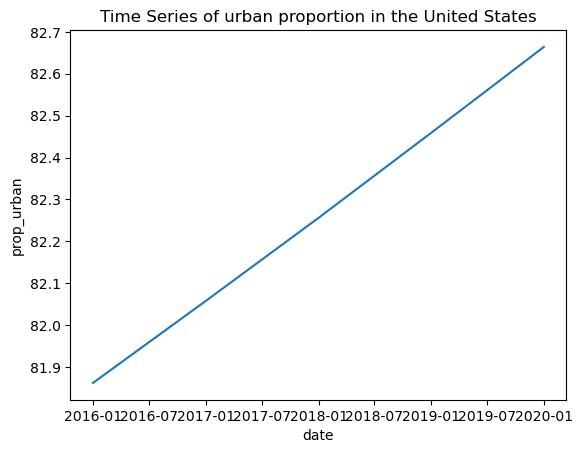

```python
# Write your own code
us = data_sorted.query('country_name == "United States"')
plt.plot(us['date'], us['prop_urban'])
plt.title('Time Series of urban proportion in the United States')
plt.xlabel('date')
plt.ylabel('prop_urban')
```

(e) Convert to wide format

- Convert "data_sorted" from long to wide, using the following arguments:

  ```
   index = 'country_name'
   columns = 'year'
   values =  'prop_urban'
  ```

- Display the dataset to check that it is in wide format

HINT: See Lecture 21 for details

```python
# Write your own code
wdi_wide = (pd.pivot(data_sorted,
                           index = 'country_name',
                           columns = 'year',
                           values =  'prop_urban'))
```